# Peer Assessment 1

Clive Petry

September 15, 2015

# Analysis of Personal Movement Using Activity Monitoring Devices

## Introduction

It is now possible to collect a large amount of data about personal movement using activity monitoring devices such as a Fitbit, Nike Fuelband, or Jawbone Up. These type of devices are part of the “quantified self” movement - a group of enthusiasts who take measurements about themselves regularly to improve their health, to find patterns in their behavior, or because they are tech geeks. But these data remain under-utilized both because the raw data are hard to obtain and there is a lack of statistical methods and software for processing and interpreting the data.

This project makes use of data from a personal activity monitoring device. This device collects data at 5 minute intervals through out the day. The data consists of two months of data from an anonymous individual collected during the months of October and November, 2012 and include the number of steps taken in 5 minute intervals each day. The goal of this project is to write a report that answers the questions detailed below.

### Loading the data (from the working directory) and processing it

```r
echo = TRUE
activity <- read.csv("activity.csv", sep=",", header=TRUE)
```

Looking at the initial entries of the data

```r
echo=TRUE
head(activity)
```

```
##   steps       date interval
## 1    NA 2012-10-01        0
## 2    NA 2012-10-01        5
## 3    NA 2012-10-01       10
## 4    NA 2012-10-01       15
## 5    NA 2012-10-01       20
## 6    NA 2012-10-01       25
```

converting date column from factor to Date class

```r
echo = TRUE
activity$date<-as.Date(activity$date)
```

### What is the mean total number of steps taken per day?

To calculate the mean number of steps per day we must first calculate the total number of steps for each day (and then show the first of them)

```r
echo = TRUE
stepsperday <- tapply(activity$steps, activity$date, sum, na.rm=TRUE)
head(stepsperday)
```

```
## 2012-10-01 2012-10-02 2012-10-03 2012-10-04 2012-10-05 2012-10-06
##          0        126      11352      12116      13294      15420
```

Then present the number of steps per day in histogram form

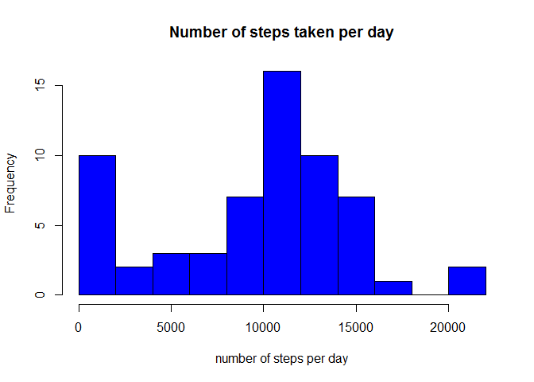

```r
echo = TRUE
hist(stepsperday, breaks=10, xlab = "number of steps per day", main = "Number of steps taken per day", col="blue")
```

Calculate the mean number of steps per day

```r
echo = TRUE
mean <- mean(stepsperday)
mean <- as.integer(mean)
```

The mean number of steps per day is 9354

Calculate the median number of steps per day

```r
echo = TRUE
median <- median(stepsperday)
median <- as.integer(median)
```

The median number of steps per day is 10395

### What is the average daily activity pattern?

To establish the 5 minute intervals, and then calculate the mean number of steps across the 5 minute intervals on the different days (showing the first of them)

```r
echo = TRUE
intervals <- tapply(activity$interval, activity$interval, mean, na.rm=TRUE)
stepsperinterval <- tapply(activity$steps, activity$interval, mean, na.rm=TRUE)
head(stepsperinterval)
```

```
##         0         5        10        15        20        25
## 1.7169811 0.3396226 0.1320755 0.1509434 0.0754717 2.0943396
```

Then plot the data

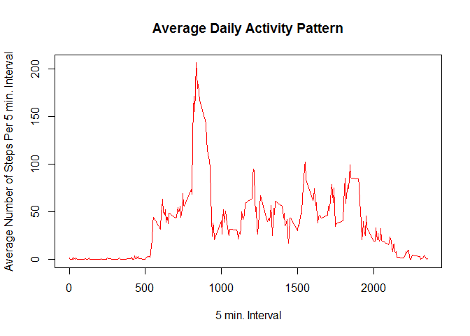

```r
echo = TRUE
plot(intervals, stepsperinterval, type="l",
     xlab = "5 min. Interval", ylab = "Average Number of Steps Per 5 min. Interval", main = "Average Daily Activity Pattern",  col ="red")
```

To find which 5-minute interval, on average across all the days in the dataset, contains the maximum number of steps and what that maximum is

```r
echo = TRUE
print(stepsperinterval[which.max(stepsperinterval)])
```

```
##      835
## 206.1698
```